# Cardio Good Fitness Project

### My Objective

As a data scientist, my goal for this project will be to develop a detailed customer profile for each of the different products offered by Cardio Good Fitness. I will utilize the data at hand to extrapolate possible trends or patterns for the customers of each different product. Based on my findings, I will determine all possible insights that will help me better understand the data at large. Using the insights and understanding gained from my analysis, I will make my recomendations to the business about how they may be able to reach new customers.

### Data Dictionary

The data is about customers of the treadmill product(s) of a retail store called Cardio Good Fitness. It contains the following variables-

1. Product - The model no. of the treadmill
2. Age - Age of the customer in no of years
3. Gender - Gender of the customer
4. Education - Education of the customer in no. of years
5. Marital Status - Marital status of the customer
6. Usage - Avg. # times the customer wants to use the treadmill every week
7. Fitness - Self rated fitness score of the customer (5 - very fit, 1 - very unfit)
8. Income - Income of the customer
9. Miles- Miles that a customer expects to run

### Import Packages

```python
import numpy as np
import pandas as pd
```

```python
import matplotlib.pyplot as plt
import seaborn as sns

%matplotlib inline
sns.set(color_codes=True)
```

### Import dataset from drvie

```python
from google.colab import drive
drive.mount('/content/drive')
```

```python
data = pd.read_csv('/content/drive/MyDrive/Python Course/CardioGoodFitness.csv')
```

```python
# create a copy of the data
df = data.copy()
```

### Overview of the Dataset

```python
# check the 1st 5 rows
df.head()
```

|  | Product | Age | Gender | Education | MaritalStatus | Usage | Fitness | Income | Miles |
| --- | --- | --- | --- | --- | --- | --- | --- | --- | --- |
| 0 | TM195 | 18 | Male | 14 | Single | 3 | 4 | 29562 | 112 |
| 1 | TM195 | 19 | Male | 15 | Single | 2 | 3 | 31836 | 75 |
| 2 | TM195 | 19 | Female | 14 | Partnered | 4 | 3 | 30699 | 66 |
| 3 | TM195 | 19 | Male | 12 | Single | 3 | 3 | 32973 | 85 |
| 4 | TM195 | 20 | Male | 13 | Partnered | 4 | 2 | 35247 | 47 |

- Data imported correctly

```python
# check the size of the data by looking at its shape
df.shape
```

```
(180, 9)
```

- There are 180 rows (customers)
- 9 columns (consisting of product information and customer demographics)

```python
# let's take a more detailed look at our data
df.info()
```

```
<class 'pandas.core.frame.DataFrame'>
RangeIndex: 180 entries, 0 to 179
Data columns (total 9 columns):
 #   Column         Non-Null Count  Dtype
---  ------         --------------  -----
 0   Product        180 non-null    object
 1   Age            180 non-null    int64
 2   Gender         180 non-null    object
 3   Education      180 non-null    int64
 4   MaritalStatus  180 non-null    object
 5   Usage          180 non-null    int64
 6   Fitness        180 non-null    int64
 7   Income         180 non-null    int64
 8   Miles          180 non-null    int64
dtypes: int64(6), object(3)
memory usage: 12.8+ KB
```

- Here we can see the breakdown of our 9 characteristic columns of the data
- There are 3 object type columns and 6 numerical columns
- There are no null values in any of the columns, all have 180 entries.

```python
# Check the mean, median, and range for the numeric columns
df.describe().T
```

|  | count | mean | std | min | 25% | 50% | 75% | max |
| --- | --- | --- | --- | --- | --- | --- | --- | --- |
| Age | 180.0 | 28.788889 | 6.943498 | 18.0 | 24.00 | 26.0 | 33.00 | 50.0 |
| Education | 180.0 | 15.572222 | 1.617055 | 12.0 | 14.00 | 16.0 | 16.00 | 21.0 |
| Usage | 180.0 | 3.455556 | 1.084797 | 2.0 | 3.00 | 3.0 | 4.00 | 7.0 |
| Fitness | 180.0 | 3.311111 | 0.958869 | 1.0 | 3.00 | 3.0 | 4.00 | 5.0 |
| Income | 180.0 | 53719.577778 | 16506.684226 | 29562.0 | 44058.75 | 50596.5 | 58668.00 | 104581.0 |
| Miles | 180.0 | 103.194444 | 51.863605 | 21.0 | 66.00 | 94.0 | 114.75 | 360.0 |

### Let's find out more about the categorical(object) variables

Since we want to try and establish customer profiles for each product, I first to need to see how many different products we have in the dataset as well as the amount of data for each product.

```python
# using the value_counts() function on the poducts columumn
# this will shows all different products and how many of each
df['Product'].value_counts()
```

```
TM195    80
TM498    60
TM798    40
Name: Product, dtype: int64
```

- We have 3 product types split into 3 different size groups.
- The TM195 product has twice as much customer data available compared to TM798. Then TM 498 sits exactly in the middle for the amount of customer data we have.
- Intuitively I would think we might be looking at a base model product, a mid-tier, and a top tier model. Without pricing data or more product info I can't say this for sure, but perhaps there will be a trend in income and fitness level that may show some correlation to fit this theory.

```python
# gender values
df['Gender'].value_counts()
```

```
Male      104
Female     76
Name: Gender, dtype: int64
```

- The male vs. female ratio of customers in the dataset is fairly close with there only being 28 more males in the dataset.
- I wouldn't expect male vs. female to have a significant difference in correlation with our other categories but that is definitely something we will need take a look at.

```python
# Marital Status values
df['MaritalStatus'].value_counts()
```

```
Partnered    107
Single        73
Name: MaritalStatus, dtype: int64
```

- The data shows that marital status is a fairly close split as well, with only 34 more being partnered vs. single.
- We will see what sort of correlation this may have amongst our other data.

### Now that we have a good overview of the data, and since no missing value treatment is required, we can move on to some exploratory data analysis.

# Univariate Analysis

### starting with our numerical values

Histograms and Boxplots are a great way to assess our numeric columns

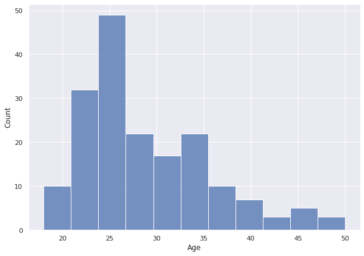

```python
# histogram for Age
plt.figure(figsize=(10,7))
sns.histplot(data=df, x='Age');
```

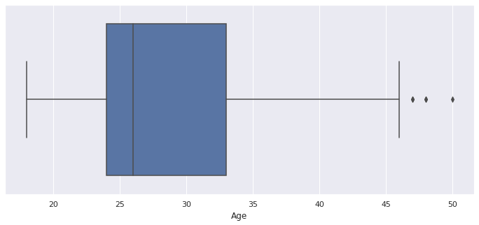

```python
# boxplot for Age
plt.figure(figsize=(12,5))
sns.boxplot(data=df, x='Age');
```

- We can see from these graphs that our Age values are right skewed and there appear to be just a few outliers past about age 46.

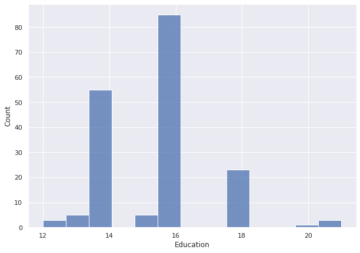

```python
# histogram for education
plt.figure(figsize=(10,7))
sns.histplot(data=df, x='Education');
```

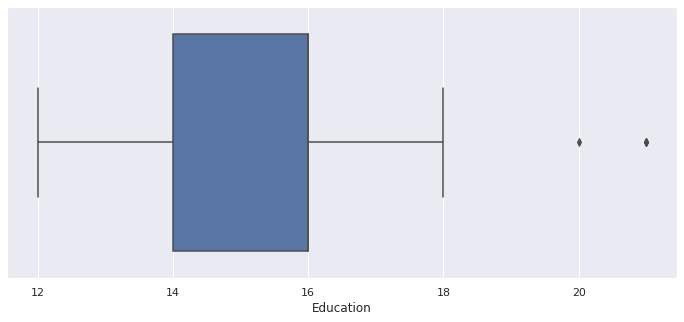

```python
# boxplot for education
plt.figure(figsize=(12,5))
sns.boxplot(data=df, x='Education');
```

- Education appears to have a bit of a right skew.
- About 85 customers have 16 years of education, this is the majority, followed by 14 years at around 55 of the customers, and the 3rd largest group is of about 25 that have 18 years of education.
- From this we can infer that the majority of customers are college educated and hold a bachelor's degree at the 16 year level.
- Our next next highest level at 14 years would potentially consist of those with an associate’s degree, a trade school, or are currently working towards their bachelor's degree.
- The 3rd largest group of 18 years would be presumed to hold a master's degree.
- The biggest takeaway though, is that it seems almost all of the customer's have at least some form secondary education. This could prove to be useful in helping to form different customer profiles.

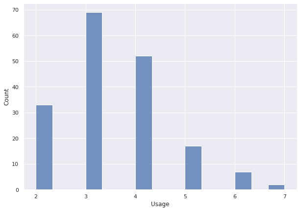

```python
# Usage histogram
plt.figure(figsize=(10,7))
sns.histplot(data=df, x='Usage');
```

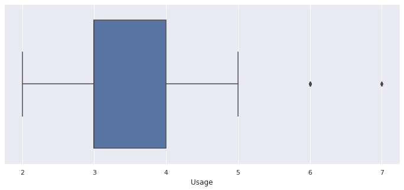

```python
# box plot for Usage
plt.figure(figsize=(12,5))
sns.boxplot(data=df, x='Usage');
```

- The usage data is right skewed
- The majority of customers (about 70) would like to use the product 3 times a week on average, followed by just over 50 who say 4 times a week, and just over 30 who said 2 times a week which was the minimum value reported.
- There are some outliers who said they would like to use the product an avg. of 6 or 7 times a week, but there are people who like to exercise daily so this is expected.

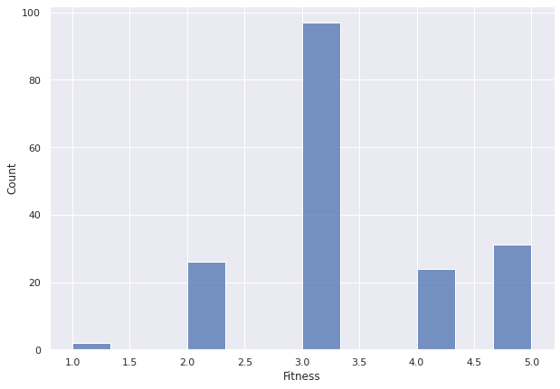

```python
# Fitness(self-score 1 to 5) Histogram
plt.figure(figsize=(10,7))
sns.histplot(data=df, x='Fitness');
```

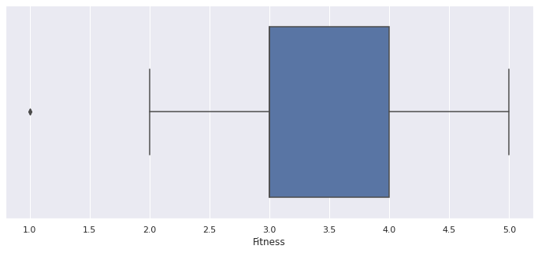

```python
# Fitness(self-score 1 to 5) Boxplot
plt.figure(figsize=(12,5))
sns.boxplot(data=df, x='Fitness');
```

- Nearly 100 rated themselves about a 3, with the remainder a close mixture of 2, 4, and 5.
- There is a slight left skew to the data with small number who rated themselves a 1.

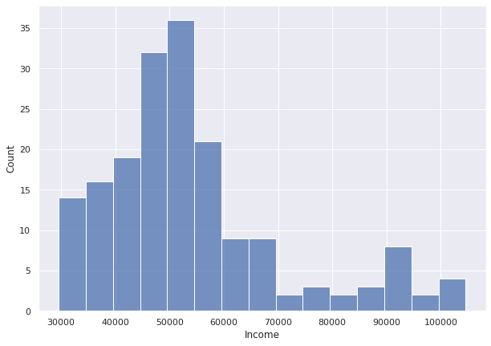

```python
# histogram for income
plt.figure(figsize=(10,7))
sns.histplot(data=df, x='Income');
```

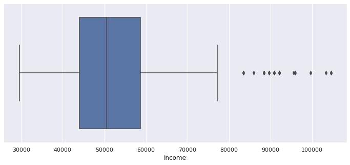

```python
# boxplot for income
plt.figure(figsize=(12,5))
sns.boxplot(data=df, x='Income');
```

- There is quite an apparent right skew to the customer income data.
- income is a lot more distributed compared to our other numerical values
- Around 50k is the highest segment of our customers but there is still a good spread from about 30k to 60k then it starts to drop off some from 60k to about 78k then it tends to outliers past there with a small spike around 90k.

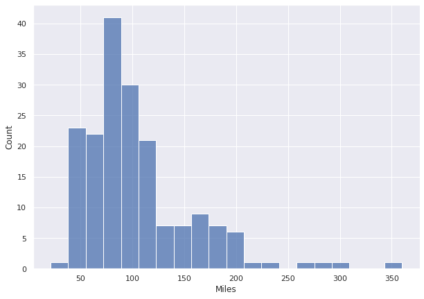

```python
# histogram for miles
plt.figure(figsize=(10,7))
sns.histplot(data=df, x='Miles');
```

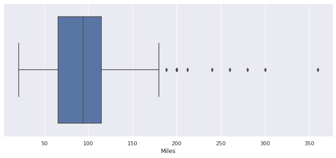

```python
# boxplot for miles
plt.figure(figsize=(12,5))
sns.boxplot(data=df, x='Miles');
```

- There is a strong right skew
- Largest amount of customers said they would like to run about 85-90k
- Most answered between 50-120k with a significant drop from 120k to about 200k followed by quite a few outliers past 200k
- This is a measure of Miles a customer expects to run though, but without a time frame it is harder to quantify these numbers. Is it this many miles a week? a month? a year? But we can try to see if there is correlation with the customers fitness level and expected number of miles regardless of time frame to see if any noticeable pattern may emerge.

## Univariate Analysis of Categorical Variables

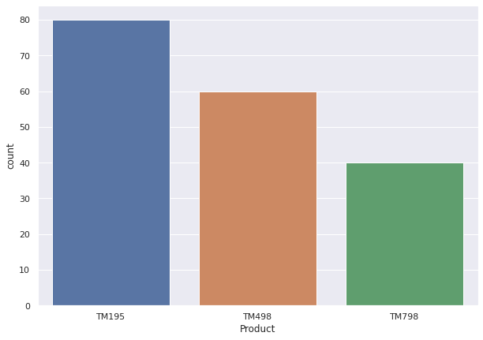

```python
# creating a countplot for Product in order to create a Univariate Analysis
# since product is a categorical variable a countplot is the best way to get an analysis
plt.figure(figsize=(10,7))
sns.countplot(data=df, x='Product');
```

- The count is neatly split between the 3 products in even steps of 20 customer records between each.
- Product TM798 has 40 customer entries in our data
- Product TM498 has 60 customer data entries
- Then Product TM195 has the most data entries between the different products at a count of 80
- I am still very interested to see if these numbers represent different tier models such as a base model, a mid-tier, and a top tier. Without pricing data from the products we can not confirm this, but some Bivariate analysis may be able to form a possible correlation to point towards this possibility.

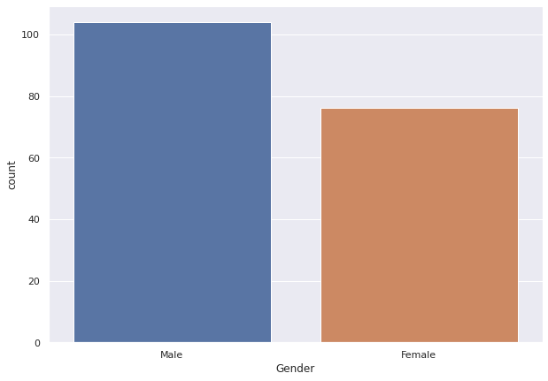

```python
# countplot for Gender
plt.figure(figsize=(10,7))
sns.countplot(data=df, x='Gender');
```

- We have a higher count of Males in our customer data at 104
- The Female customer count is 76
- This is only a difference of 28 between Male and Female customer entries
- We will need to see if Male vs. Female will have any correlation on product choice or fitness level.

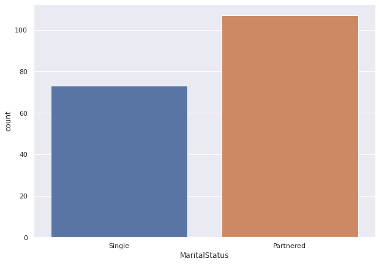

```python
# countplot for Marital Status
plt.figure(figsize=(10,7))
sns.countplot(data=df, x='MaritalStatus');
```

- We have more partnered customer entries in our data at 107
- The single count for our customer data is at 73
- This is a difference of 34 customers in Marita Status Partnered vs. Single
- We saw in our Gender graph that there was a difference of 28 Male vs. Female. These numbers, 28 Gender difference vs. 34 Marital Status difference, are pretty close. It will be interesting to see if there is a possible correlation between Male vs. Female in relation to Marital Status in our data.

# Bivariate Analysis

We have taken a look at the Univaiate Analysis for all of our data columns individually in order to gain some basic insights. Now it is time to compare our different variable columns with each other in order to establish some trends and correlations that will help us in creating customer profiles for each of the products.

### Analysis of Products

I would first like to start with comparing our three products against our other variables to see if any trends emerge.

### Products with respect to Age

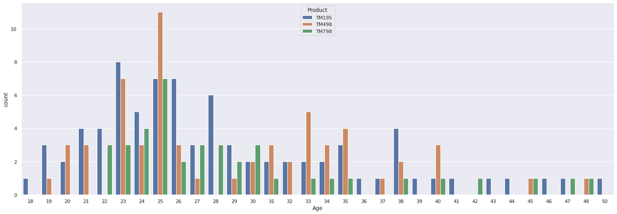

```python
# creating a countplot to compare sales of each product type by individual ages
plt.figure(figsize=(24,8))
sns.countplot(data=df, x='Age', hue='Product');
```

- The 3 products do not seem to have a strong correlation with age range for any individual product, as the product types have a mixed distribution amongst the entire age range. There are a few key insights we can observe though.
- Age 23 has the highest count, for a single age, of product TM195 at 8 units.
- The age with the highest count for product TM 498 is 25 years old with 11 units. 11 units is the highest single age sales number of the three products.
- Age 25 also happens to have the highest count for product TM798 as well.
- Age 25 has a count of 7 units for product for TM195, which is only 1 less than the highest count of 8.
- This makes Age 25 seem to be a clear target Age for all 3 products and the Age with the overall greatest combined sales.
- Another observation is that there are no sales for Product TM798 in the 18-21 years of Age range.
- The youngest end of the Age range is not in the market for TM798, this may be a potential new area to expand sales of Product TM798, or perhaps another trend is causing no sales of TM798 to the youngest customers.

### Product Customers by Gender

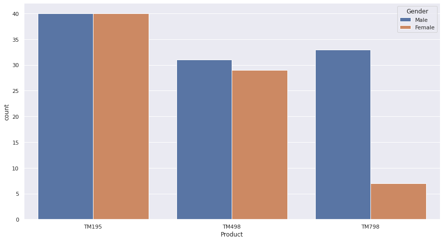

```python
# countplot for products and gender
plt.figure(figsize=(15,8))
sns.countplot(data=df, x='Product', hue='Gender');
```

### Products by customer Education(in years)

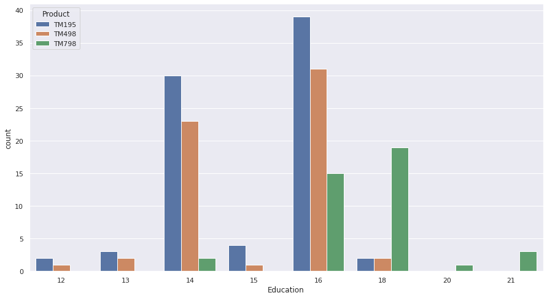

```python
# countplot to compare each product to education levels
plt.figure(figsize=(15,8))
sns.countplot(data=df, x='Education', hue='Product');
```

- From education level we can see that our highest concentration of customers tend to have 16 years of education. We can infer that this is the equivalent of 4 years of college equating to a bachelor’s degree.
- The second largest concentration of customers is at 14 years of education. We can infer this as being either an associate's degree, trade school program, or those that are currently in school working towards a bachelor's degree.
- So the majority of our customer base is shown to have some level of secondary education.
- The product splits between TM195 and TM498 seem to be close to proportionate between 14 and 16 years of education relative to the number of customers at each level.
- A more apparent trend seems to be that product TM798 is almost exclusively preferred by customers with 16 years of education and up, with the exception of 2 customers at 14 years.
- The majority of product TM798 can be found at 18 years of education and only about 2 sales each of the other products at the 18 year level.
- Then those with higher than 18 years only preferred TM798.
- This seems to indicate a correlation between education level and product preference.

### Products and Marital Status

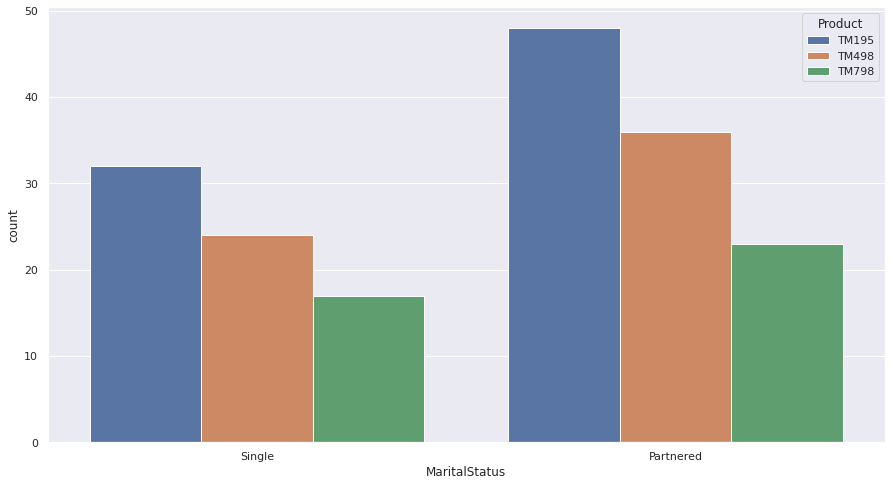

```python
# countplot to compare marital status of customers to each product
plt.figure(figsize=(15,8))
sns.countplot(data=df, x='MaritalStatus', hue='Product');
```

- Very similar descending step pattern between product type and Marital Status proportionate to the greater amount of partnered customers vs. single.
- No strong correlation of any one product type being greater in single vs. partnered.
- More customers tend to be partnered.
- Perhaps the single customer market could be an area to expand sales.

### *Products* by Customer Usage(Avg. number of times a week)

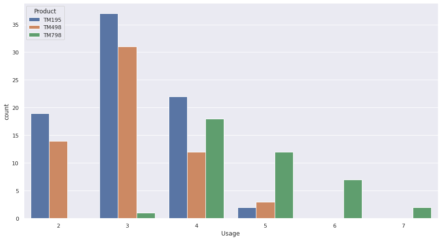

```python
# countplot comparing usage to product type
plt.figure(figsize=(15,8))
sns.countplot(data=df, x='Usage', hue='Product');
```

- Overall customers plan to use their product an average of 3 times a week.
- Customers of product TM195 and TM498 tend to be more on the lower half of usage numbers with most between 2-4 times a week on average.
- TM798 is on the higher side with the majority being 4 times a week and up on average.
- Only customers of product TM798 said they would like to use their product 6 or 7 times a week.
- TM798 seems to be the preferred product of customers who plan to exercise more times a week on average.

### Product vs. Customer Fitness Level(scale of 1-5)

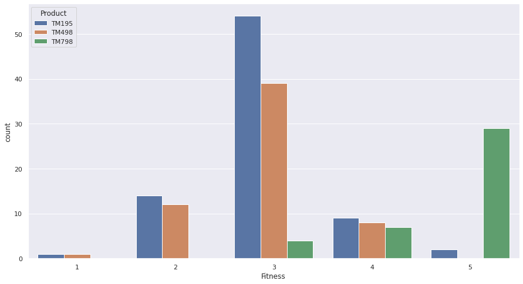

```python
# creating a countplot to compare products by fitness levels
plt.figure(figsize=(15,8))
sns.countplot(data=df, x='Fitness', hue='Product');
```

- The highest score amongst customer's self fitness rating is right in the middle at 3.
- Almost all customers who responded 3 are using either product TM195 or TM498, with TM195 being the greater number.
- Only 2 people out people out of 180 customers gave themselves a rating of 1.
- Another trend is that customers of product TM798 only rated themselves 3 and above, with the majority of TM798 customers giving themselves a rating of 5. In face customers who rated themselves were almost entirely customers of product TM798
- We can infer that customers of product TM798 consider themselves to be more fit than customers of the other 2 products.

### Products based on Customer Income

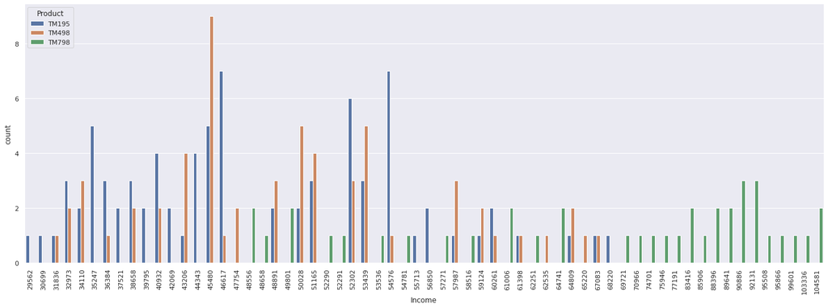

```python
# countplot to see product type distribution by income level
plt.figure(figsize=(24,8))
sns.countplot(data=df, x='Income', hue='Product');
plt.xticks(rotation=90);
```

- Product sales are fairly distributed amongst different income levels with 9 units sold being the highest amount of an individual product for a single income level. This being product TM498 at 45,480
- 45,480 also has the highest combination of units sold for a single income level with 14 units, 9 being TM498 and 5 being TM195.
- The only product sold under 31,000 is TM195.
- Sales of product TM798 don't start until around 48,556 and extend all the way to the top income level at 104,581
- Sales of TM195 and TM498 completely stop after 68,220
- This shows a clear trend where product TM798 is not sold at all to customers with income under about 48,000 and then it is the only product sold to customers with over 69,000 of income.
- We can infer that product TM798 seems to be a more expensive model compared to the other 2 products based on it being the only product sold to the customers with the highest income level.
- We can also infer that products TM195 and TM498 seem to be seem to be pretty similar in price as they are both distributed similarly in income levels, TM195 perhaps being a little lower price as it is the only one sold at the lowest income range under 31,000

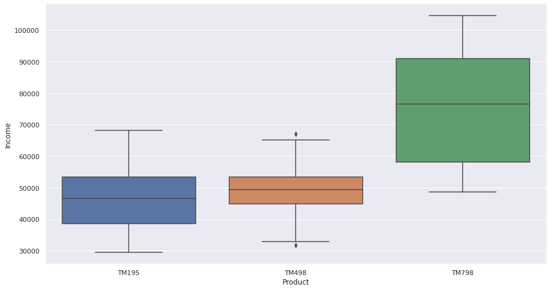

```python
# creating a boxplot for income levels to see a more distinct picture of out above observations
plt.figure(figsize=(15,8))
sns.boxplot(data=df, x='Product', y='Income');
```

- The boxplot better illustrates the majority sales range as well as the median income for each.
- This confirms our above findings where TM195 and TM498 customers are fairly close in income levels with TM498 having a slightly higher median income along with a slightly higher starting income.
- This boxplot makes it even more apparent as to the much higher income levels for customers of product 798. The Median income level for product 798 is even above the top range whiskers for the boxplots of the other 2 products.

### Products and Customer Miles

This category I infer to be just another general gauge of customer's self reported fitness level similar to the 1-5 rating. I say this as there is no time frame given for these Miles. So without knowing if these are expected miles they would like to run per week, month, or year, it is hard to gauge this category as anything other than customers idea of their self fitness level based on general expectations.

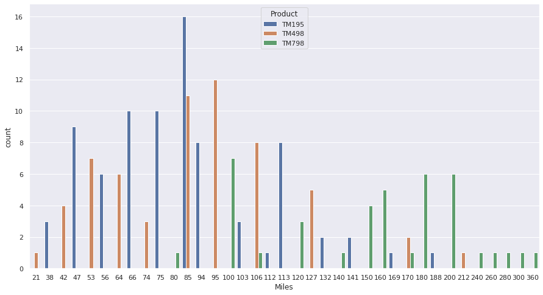

```python
#countplot for Product and Miles
plt.figure(figsize=(15,8))
sns.countplot(data=df, x='Miles', hue='Product');
```

- 85 and 95 miles have the highest customer count for product TM195 and TM498 respectively.
- At 150 and up it becomes a majority of TM798 customers and 240-360 is entirely customers of TM798.
- This seems to correlates with the results of the fitness level 1-5 as product TM798 was at the top end of that as well being mostly for customers rating their fitness level 5, so it makes sense that customers of product 798 also have the highest expectations for miles to run.
- From this we can infer that customers of product TM798 definitely see themselves as more fit.

Now that I have gotten a better picture of our customer's demographics in relation to each product type, it is time to look at some of the trends we saw in more detail to confirm some of our findings.

### Heatmap

I would first like to look at a heatmap for our data set in order to confirm which of the correlations we observed above are actually the strongest.

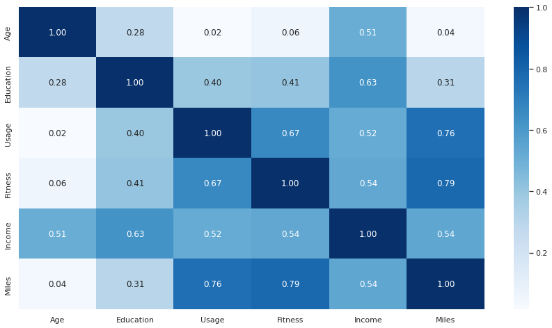

```python
# creating a heatmap for our data
corr=df.corr()
plt.figure(figsize=(15,8))
sns.heatmap(corr, annot=True, fmt='.2f', cmap='Blues');
```

- It looks like the strongest correlation is between Fitness and Miles at 0.79
- We also have a pretty close 2nd between Usage and Miles at 0.76
- Fitness and Usage correlate a little less with each other at 0.67
- Education seems to have some correlation with income at 0.63

These correlations make sense as the customer's sense of their self fitness rating, expected usage, and expected miles, should be in line with each other. People would generally have a good sense of their exercise levels and goals which would compare relatively across all 3 of these categories.

- Education and Income being correlated is a typical expectation to see in general, so there is no surprise that they have some correlation amongst the our customer data

The others being at close to 0.5 or less aren't showing very strong correlations with each other. There is still some observations we can take from these lower correlations.

- Age seems to have very little correlation with any of the other categories. It has the lowest correlations with all of them except for some with income at 0.51.

### Pairplot

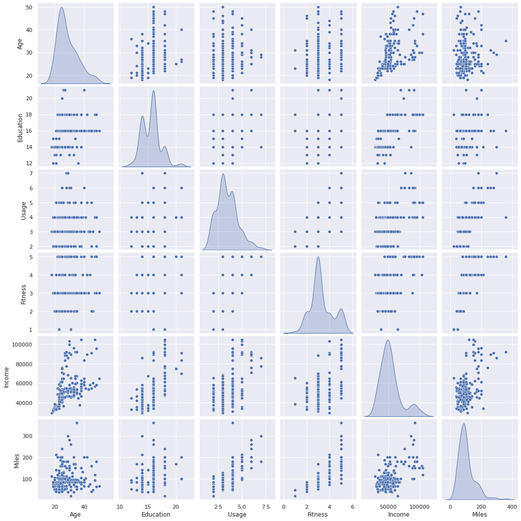

```python
#creating a pair plot for our data to see a different representation of the correlations
sns.pairplot(data=df, diag_kind='kde')
plt.show()
```

Here we can see a more visual representation of what we saw in our heatmap

# Multivariate Analysis

- It is one thing to observe trends by comparing each category to product type individually, but to really understand our customer base we will need to look at multiple categories simultaneously.
- By combining multiple variables, in the same graph, with relation to product type we will create a more in depth look at forming customer profiles.

### Education and Income by Product type

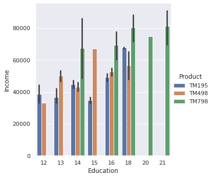

```python
# to create a bar graph for this comparison we need to use a catplot and not a countplot
# we use the catplot instead because a countplot won't let us pass both an x and y variable
sns.catplot(data=df, x='Education', y='Income', hue='Product', kind='bar');
```

- This confirms the correlation we saw in our heatmap between between years of education and income
- There seems to be a clear preference for product TM798 at both a higher education level as well as a higher income level for our customer data.

### Customer Usage(weekly) and Miles(customer reported expectation) by Product type

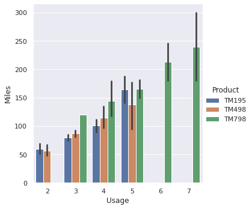

```python
# use ancatplot in making a bar graph for usage and miles
sns.catplot(data=df, x='Usage', y='Miles', hue='Product', kind='bar');
```

- Here we can see a very noticeable positive correlation between Usage and Miles
- This shows a definite trend between the number of times a week that the customer intends to use the product and their self reported miles they expect to run.
- This makes sense as the generally the more fit you see yourself, the greater the miles you would expect to run using the product.
- we can also observe that product usage is fairly mixed between all 3 products in the middle, but the twice a week usage segment does not contain product TM798.
- Customers who plan to use the product more than 5 times a week are exclusively users of product TM798.
- From this I would infer that product TM798 is the product for customers looking to get the most usage and miles out of their product.

### Fitness(customer self score 1-5) and Miles by Product type

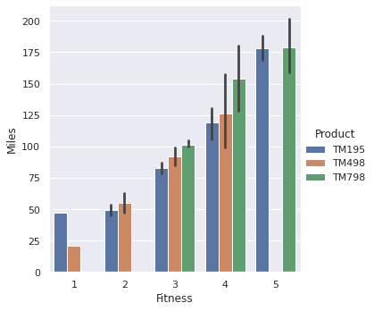

```python
# create a catplot to show the bar graph for these variables
sns.catplot(data=df, x='Fitness', y='Miles', hue='Product', kind='bar');
```

- This was the highest correlation out of all categories in the data
- It makes perfect sense as the more fit you see yourself the more confident you are in your ability to run more miles.
- somewhat similar to what we saw above with usage, product TM798 is missing from the lower end of customer fitness score at the 1-2 level.
- TM798 is on the high side of fitness scores in respect to miles having the highest number at score 5, but customers of product TM195 who also identify as a 5 expect a very similar number of miles, up to a point.
- No users of product TM498 gave themselves a fitness score of 5

# Outlier Treatment

- It's good to take a look at the outliers in your data all together in order to make sure they make sense or see if any of our columns may need to be treated.

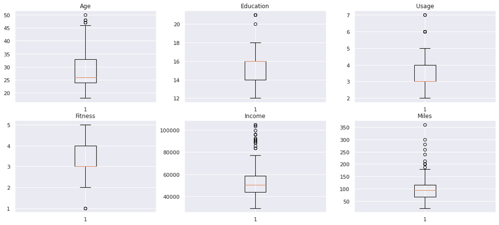

```python
# boxplots are one of the best ways to visually see your outliers side by side
# for this to work we need to put all the numeric columns in to a list
numeric_cols = ['Age', 'Education', 'Usage', 'Fitness', 'Income', 'Miles']
plt.figure(figsize=(18,12))

for i, variable in enumerate(numeric_cols):
  plt.subplot(3,3, i+1)
  plt.boxplot(df[variable], whis=1.5)
  plt.tight_layout
  plt.title(variable)

plt.show()
```

It looks like we have at least 1 outlier in every column and some with quite a few such as Income and Miles.

- With Age there will always be a wider range of customers interested in fitness so we wouldn't want to treat these and lose information important to customer profiles. We can potentially better see which products attract which age range to better advertise each product accordingly.
- Education is also expected to have a range with customers, and knowing where are customers are at in education level could be helpful in product marketing as well.
- Income has a lot of outliers, but since we want to establish customer profiles for each product, knowing which product attracts higher income customers is very valuable information and we would not want to drop these outliers.
- Usage, Fitness, and Miles are all customer reported information based on their assessments and expectations. This gives us valuable insight into how the customers of each product view themselves in relation to fitness level and what they expect to get out of their product. This is essentially our user feedback and there will always be a wide range in answers as everyone will view their situation differently. The trends we see develop through their self reported answers are just as much, if not more, insightful than any of the other static demographic information.

Based on my analysis of our categories, we do need to do any outlier treatment, because in the broader scope of customer base and product profiles all of these outliers constitute valuable information that should not be dropped.

# Conclusive Insights

## Product TM195

- TH195 is fairly distributed throughout age ranges, but your target demographic would be ages 23-28, with 23 being the majority age for this product.
- Gender is evenly split
- Primarily customers have 14 or 16 years of education with more having 16 years
- There were more partnered customers than single, but this was the overall trend for the dataset so I wouldn't put too much weight behind this statistic
- Customers of TM195 said they would like to use the product 2-4 times a week with 3 being the highest response.
- While this product's overall customer income ranged from roughly 29,000 to 68,000, this was the only product sold under about 31,500. The largest customer segment though was in the 35,000 to 55,000 range
- On a scale of 1-5 most customers rated themselves a 3 so mostly moderately fit people are using this product.
- while there was a large range on customer expectations for miles, the majority of customers fell between 47-113 miles. This shows both casual and more serious runners use this product.

## Producut TM798

- Target age of 22-30 for largest customer segment with 24-25 being the highest part.
- Significantly higher Male customer base
- education 16 and 18 years with 18 years being the highest amongst customers. Also of note, TM798 was the only product sold to any customer beyond 18 years of education.
- Customer response was 4 to 7 times a week for usage with 4 being the highest answer, but TM798 was the only product with customers saying they would use it 6 or 7 times a week
- The majority of TM798 customers reported their fitness level as a 5
- While incomes ranged from 48,000 to 105,000, TM798 was the only product sold to customers with incomes higher than 70,000 and the higher number of customers for this product were in the 90,000 range. While this product may have some customers with income as low as 48,000, This is definitely the sole product choice of those with the higher incomes.
- Customer Miles were also reported higher for TM798 at the main interval being between 100-200 miles there were even customers responding with 240-360 miles. No other products had customer responses near that high.

# Recommendations for reaching new customers

Based on my findings Cardio Good Fitness could look into some of the followings suggestions as to new target markets for each of their products.

- Product TM 195 already has a unique position in one portion of the customer income base. This product is the only one reaching customers with below roughly 31,500 in income. It is not very many customers though and, while also smaller, TM195 still has more customers in 12-13 years of education than others. The above research shows that there is some correlation between income level and education which seems to reflect here. So since there is already a small footing in the door with this market segment, it would be an open and already somewhat introduced market with great possibilities. It would also help drive TM195 sales into a more differentiated market position, because right now TM195 and TM498 seem to share a lot of the same demographic. Making this shift would help to stop TM195 and TM498 from cannibalizing each other's market share.
- Product TM498 has the highest number of customers from the 23 to 25 age range, but there is a smaller, yet noticeable, uptick in customers for the 31-35 age range. This is one area where TM498 shows some different customer interest. Another interesting fact was that no customers of TM498 rated themselves a 5 on their self fitness scores when the other products both had some. These are two of the more unique differences I was able to see for TM498 because otherwise it is fairly similar to product TM195 with regard to the main age level, gender split, education, and usage. So perhaps marketing to those ages 31-35 and marketing it as a product for those not 5 out of 5 in their fitness confidence already, but as the product to get them there. This is a position where there is some difference from product TM195 and they should look into expanding into this customer segment in order to help with the overlap in customers between products TM498 and TM195
- Product TM798 is the clear stand out for being a different product. It is the elite model for those with a higher level of education, a higher income, those who consider themselves mostly 5 out 5 fit already and will use this product 6 to 7 times a week to run more than 240 miles. Now these are all examples of where it differentiates from the other two products, but it does have a wider range of customers for all of these categories not just the top percent. So while this product seems to already know its customer base and be reaching its own market segment, that is entirely different from the other two products, the one big area where they are lagging behind is in gender. The other two products seem to do equally well with both men and women, but TM798 has a highly male dominated consumer base. Product TM798 needs to stay at its high level status appeal but find a way to reach more women in order to close the gender gap as the other two products have done.

```python
!jupyter nbconvert --to html /content/JonathanHutcheson_Fitness_Project.ipynb
```

[output not shown]

[output cut: 107 more lines]

[output not shown]